# Create monophyletic pairs

Stefano Giulieri

08/02/2021

Here we inspect the ST239 subtree and define clusters of contrasting clinical mortality

```r
library(tidyverse)
library(ggtree)
library(ape)
library(phytools)
rm(list = ls())
```

# The raw data

Phylogenetic tree

```r
f <- "Genetic_pairs_analysis_Oct_2020/raw_data/trees/all_snippy_BPH2947/iqtree.treefile"

tree <- read.tree(f) %>%
  phytools::midpoint.root() %>%
  ape::drop.tip("Refere-ce")
rm(f)
```

Calculate cophenetic distance

```r
m <- ape::cophenetic.phylo(tree)
str(m)
```

```
##  num [1:843, 1:843] 0 0.000762 0.000693 0.000724 0.000784 ...
##  - attr(*, "dimnames")=List of 2
##   ..$ : chr [1:843] "BPH2700" "BPH2876" "BPH2877" "BPH2763" ...
##   ..$ : chr [1:843] "BPH2700" "BPH2876" "BPH2877" "BPH2763" ...
```

```r
df_dist <- as_tibble(m, rownames = "iso1") %>%
  pivot_longer(starts_with("BPH"),
               names_to = "iso2", values_to = "dist")

rm(m)
```

Metadata

```r
df_metadata_all <- read_csv("Ideas_Grant_2020_analysis/Raw_data/strain_metadata_corrected_mortality_with_controls.csv") %>%
  filter(sample_id %in% tree$tip.label)
```

# Functions

Function to get MRCA of strains belonging to the same ST. This assumes that

- all strains with the same ST are monophyletic
- there are some on strains within the same clade that have a different ST but these different ST are assumed to one locus changes

Thus, this function defines clonal complex based on the tree topology

```r
get_st_mrca <- function(st){
  tips <- df_metadata_all %>%
    filter(ST == st) %>%
    .$sample_id
  node <- ape::getMRCA(tree, tips)
  return(node)
}
```

Function to get MRCA of all tips in the cluster

```r
get_cluster_mrca <- function(my_cluster){

  df <- df_cluster_monophy %>%
    filter(cluster_name == my_cluster)
  tips <- df$sample_id
  node <- ape::getMRCA(tree_st239, tips)
  return(node)
}
```

Function to check that a group of tips are monophyletic. It identified the MRCA of the tips and thenreturns a tree dataframe with all descendants. if the tips are monophyletic, the descendant will be the same

```r
check_if_monophyletic <- function(tree, # tree as phylo object
                                  metadata, # metadata must contain the character columns sample_id, mortality, ST. Sample if must be first colun
                                  tips){ # character of tips
  node <- ape::getMRCA(tree, tips)
  desc <- phytools::getDescendants(tree, node)
  df <- ggtree(tree) %<+% metadata %>%
    filter(node %in% desc & isTip) %>%
    transmute(parent, node, label, ST, mortality, is_in_input_tips = label %in% tips)
  return(df)
}
```

Function to plot mortality on tree

```r
plot_tree_mortality <- function(tree, # tree as phylo object
                                metadata,# dataframe of metadata. Must contain character columns sample_id, mortality
                                m_offset = 0){
  matrix <- df_metadata %>%
    select(sample_id, mortality) %>%
    column_to_rownames("sample_id")

p <- gheatmap(ggtree(tree),
              matrix , width = .04, colnames = F, color = NA, offset = m_offset) +
  scale_fill_manual(values = c("navy", "orange"), name = "Patient outcome", na.translate = F)

return(p)
}
```

Function to plot mortality clusters as a heatmap

```r
plot_clusters_heatmap <- function(tree, # tree as phylo object
                                  metadata, # dataframe of metadata. Must contain character columns sample_id, mortality, cluster_name
                                  offset = 20){ # colnames offset
  matrix <- metadata %>%
    ungroup() %>%
    select(sample_id, mortality, cluster_name) %>%
    arrange(cluster_name) %>%
    pivot_wider(names_from = cluster_name, values_from = mortality) %>%
    column_to_rownames("sample_id")

  p <- gheatmap(ggtree(tree),
                matrix,
                colnames_position = "top", colnames_angle = 90, colnames_offset_y = offset, color = NA) +
    scale_fill_manual(values = c("navy", "orange"), name = "Patient outcome", na.translate = F)

  return(p)

}
```

# The CC 239 tree

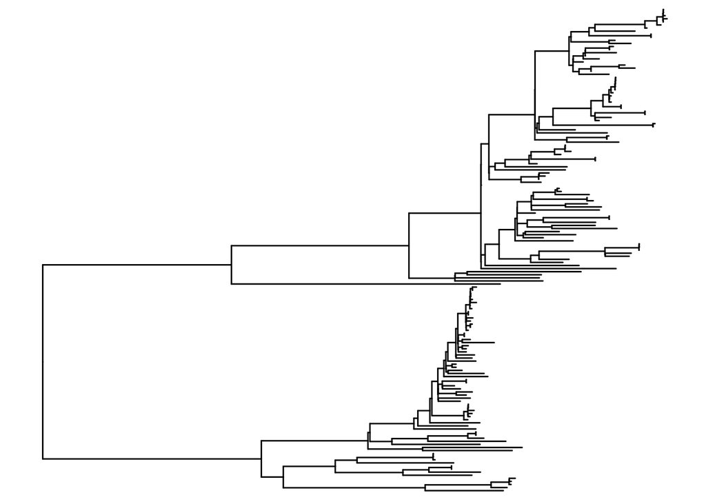

```r
node <- get_st_mrca(239)
tree_st239 <- treeio::tree_subset(tree, node, levels_back = 0)
ggtree(tree_st239)
```

```r
df_metadata <- df_metadata_all %>%
  filter(sample_id %in% tree_st239$tip.label)

# Number of sequences
nrow(df_metadata)
```

```
## [1] 157
```

```r
# Breakdown by ST
df_metadata %>%
  count(ST, sort = T)
```

```
## # A tibble: 4 x 2
##   ST        n
##   <chr> <int>
## 1 239     140
## 2 -        11
## 3 1282      5
## 4 368       1
```

```r
rm(node)
```

Plot mortality on the tree

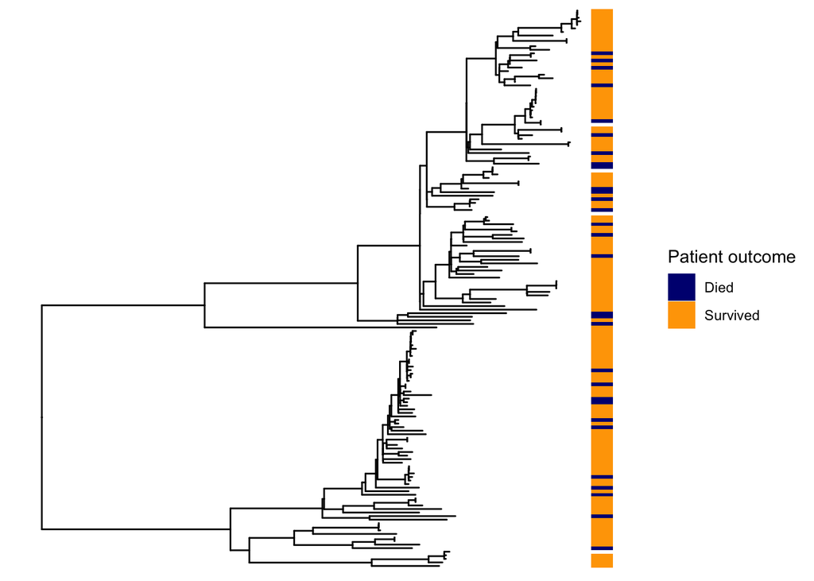

```r
plot_tree_mortality(tree_st239, df_metadata)
```

Colour labels according to mortality and export as large pdf for visualisation of monophyletic clades of lethal case strain - non lethal control strains

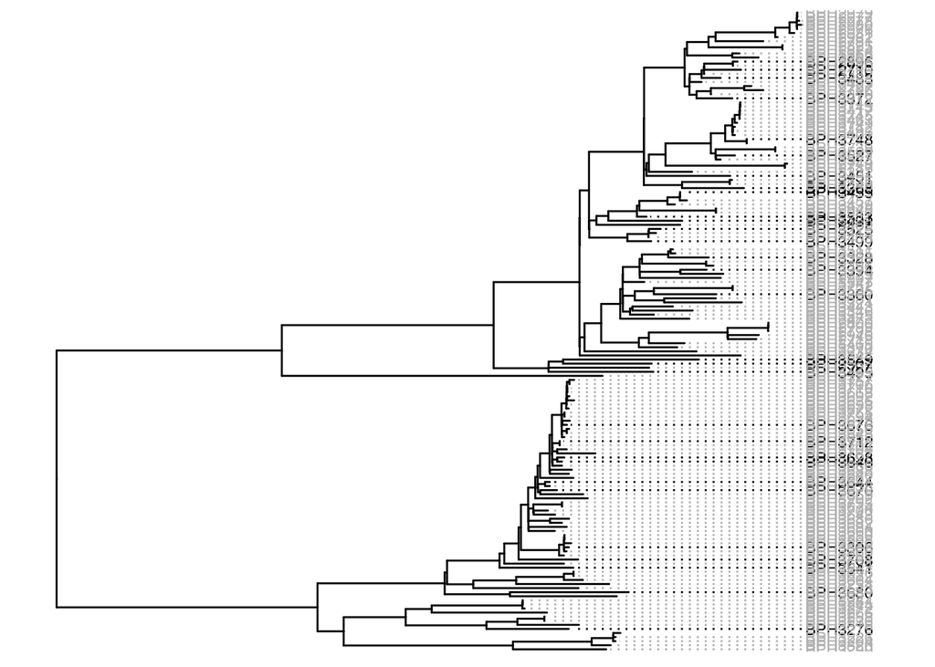

```r
ggtree(tree_st239) %<+% df_metadata +
  geom_tiplab(aes(colour = mortality), align = T, size = 3) +
  scale_color_manual(values = c("black", "grey"), na.translate = F, guide = F) +
  xlim(0,.0016)
```

```r
ggsave("Genetic_pairs_analysis_Oct_2020/figures/tmp/st239_subtree_labels.pdf", width = 12, height = 15)
```

Export tree dataframe for easy editing

```r
ggtree(tree) %<+% df_metadata %>%
  .$data %>%
  select(parent:mortality) %>%
  filter(isTip) %>%
  arrange(desc(y)) %>%
  write_csv("Genetic_pairs_analysis_Oct_2020/processed_data/tmp/st239_tree_data.csv")
```

The cladogram might help solve tricky cases

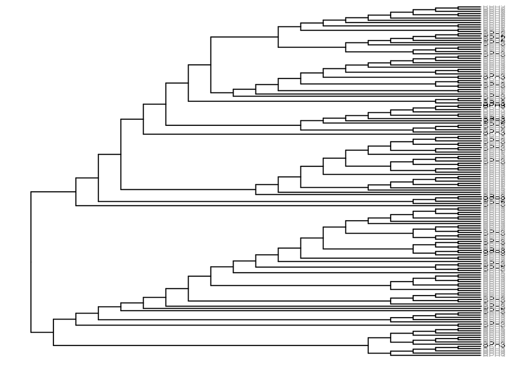

```r
ggtree(tree_st239, branch.length = "none") %<+% df_metadata +
  geom_tiplab(aes(colour = mortality), align = T, size = 3) +
  scale_color_manual(values = c("black", "grey"), na.translate = F, guide = F)
```

Alternatively, check that the selected tips are monophyletic

```r
tips <- c("BPH2710", "BPH3382")
check_if_monophyletic(tree_st239, df_metadata, tips)
```

```
## # A tibble: 4 x 6
##   parent  node label   ST    mortality is_in_input_tips
##    <int> <int> <chr>   <chr> <chr>     <lgl>
## 1    182   136 BPH2710 239   Died      TRUE
## 2    183   137 BPH2780 239   Survived  FALSE
## 3    183   138 BPH2896 239   Died      FALSE
## 4    181   139 BPH3382 239   Survived  TRUE
```

```r
rm(tips)
```

# Reimport the monophyletic clusters

```r
df_cluster_monophy <- read_csv("Genetic_pairs_analysis_Oct_2020/processed_data/tmp/st239_tree_data_monophyletic_clusters.csv")
```

Modify the dataframe of clusters

- remove samples/tips not in clusters
- create a cluster name based on the cluster number and the sample id of the lethal (case) strain
- join dataframe of cophenetic distance between controls (iso1) and case strains (iso2)

```r
df_cluster_monophy <- df_cluster_monophy %>%
  drop_na(cluster) %>%
  group_by(cluster) %>%
  transmute(sample_id = label,
            mortality,
            ST,
            cluster_case_sample_id = sample_id[which(mortality == "Died")],
            cluster_name = str_c(formatC(cluster, digits = 1, format = "d", flag = "0"),
                                 "_",
                                 cluster_case_sample_id),
            n_strains = n()) %>%
  left_join(df_dist, by = c("sample_id" = "iso1",
                            "cluster_case_sample_id" = "iso2"))
```

Plot the new clusters on the tree and check if monophyletic

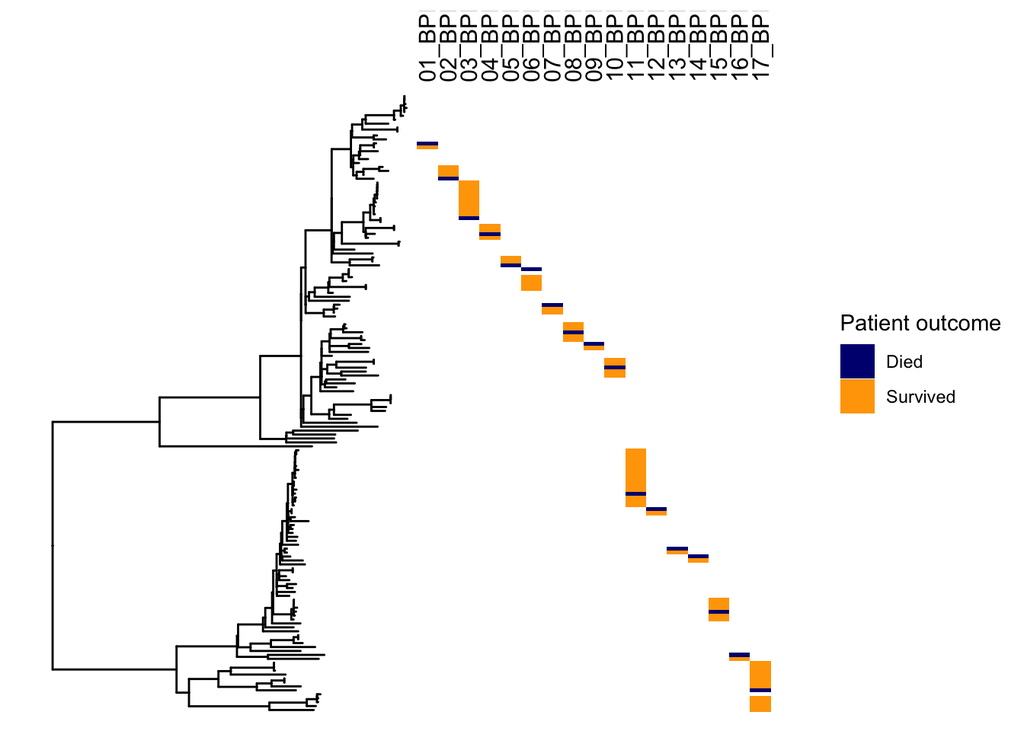

```r
plot_clusters_heatmap(tree_st239, df_cluster_monophy)
```

Alternative way to check that cluster are monophyletic

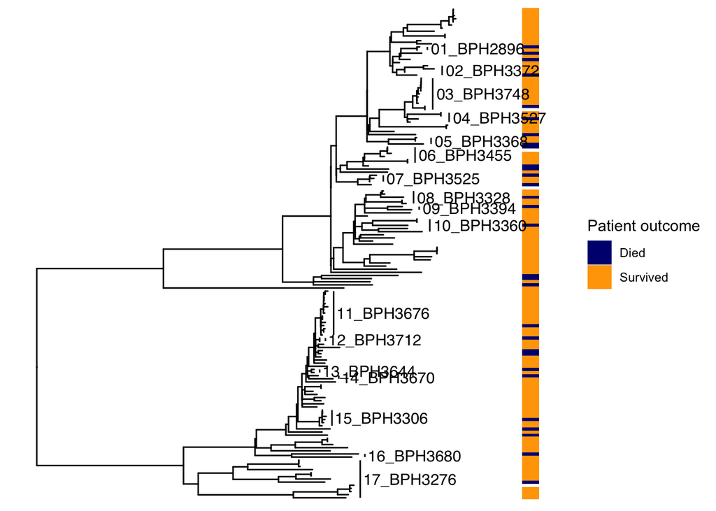

```r
p <- plot_tree_mortality(tree_st239, df_metadata, m_offset = 2e-4)
for (i in unique(df_cluster_monophy %>%  .$cluster_name)){
   node <- get_cluster_mrca(i)
   p <- p +
     geom_cladelabel(node = node, label = i)
 }
p
```

```r
ggsave("Genetic_pairs_analysis_Oct_2020/figures/tmp/st239_subtree_new_clusters.pdf")
rm(node, i)
```

Explore distribution of the cophenetic distance across the clusters

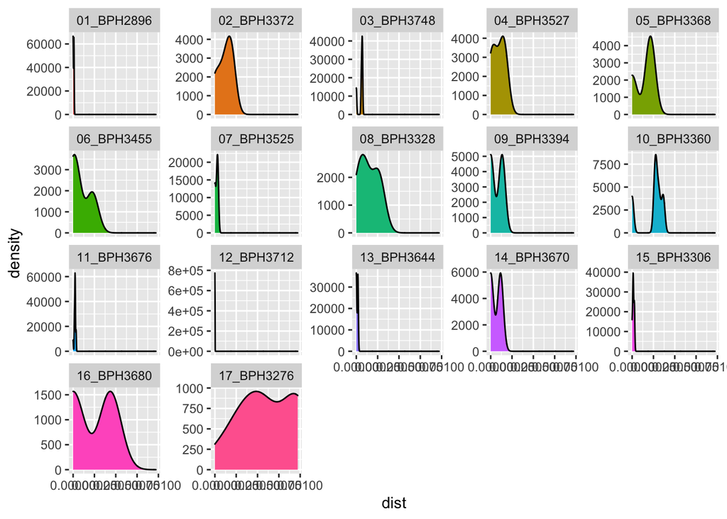

```r
df_cluster_monophy %>%
  ggplot(aes(x = dist, fill = cluster_name)) +
  geom_density() +
  facet_wrap(~cluster_name, scales = "free_y") +
  theme(legend.position = "none")
```

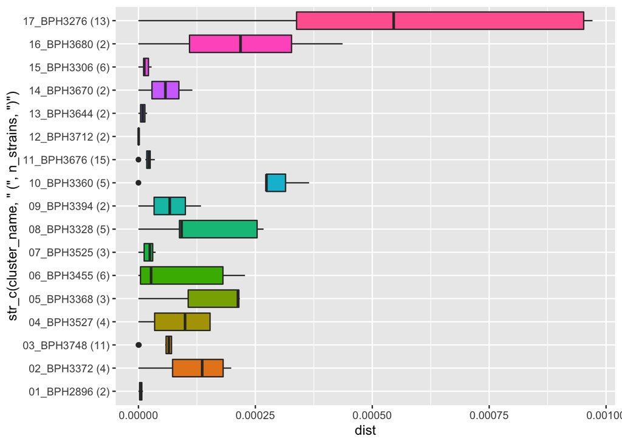

```r
df_cluster_monophy %>%
  ggplot(aes(x = str_c(cluster_name, " (", n_strains, ")"),
             y = dist,
             fill = cluster_name)) +
  geom_boxplot() +
  coord_flip() +
  theme(legend.position = "none")
```

The cluster 17 appears problematic with longer distance to the case strain and heterogeneous distances. It is also too large. Cluster 11 is also very large, but very limited genetic distance, so we will keep it for now

# Reduce size of cluster 17

```r
df_cluster_monophy %>%
  filter(cluster == 17) %>%
  arrange(dist)
```

```
## # A tibble: 13 x 8
## # Groups:   cluster [1]
##    cluster sample_id mortality ST    cluster_case_sa… cluster_name n_strains
##      <dbl> <chr>     <chr>     <chr> <chr>            <chr>            <int>
##  1      17 BPH3276   Died      239   BPH3276          17_BPH3276          13
##  2      17 BPH3258   Survived  -     BPH3276          17_BPH3276          13
##  3      17 BPH3236   Survived  -     BPH3276          17_BPH3276          13
##  4      17 BPH3316   Survived  -     BPH3276          17_BPH3276          13
##  5      17 BPH3284   Survived  239   BPH3276          17_BPH3276          13
##  6      17 BPH3244   Survived  239   BPH3276          17_BPH3276          13
##  7      17 BPH3272   Survived  239   BPH3276          17_BPH3276          13
##  8      17 BPH3266   Survived  239   BPH3276          17_BPH3276          13
##  9      17 BPH3290   Survived  1282  BPH3276          17_BPH3276          13
## 10      17 BPH3320   Survived  1282  BPH3276          17_BPH3276          13
## 11      17 BPH3204   Survived  1282  BPH3276          17_BPH3276          13
## 12      17 BPH3226   Survived  1282  BPH3276          17_BPH3276          13
## 13      17 BPH3292   <NA>      1282  BPH3276          17_BPH3276          13
## # … with 1 more variable: dist <dbl>
```

```r
# These 4 strains form a monophyletic clade
tips <- df_cluster_monophy %>%
  filter(cluster == 17) %>%
  arrange(dist) %>%
  slice_head(n = 4) %>%
  .$sample_id
tips
```

```
## [1] "BPH3276" "BPH3258" "BPH3236" "BPH3316"
```

```r
# Now edit dataframe
df_cluster_monophy <- df_cluster_monophy %>%
  filter(cluster != 17 |
           (cluster == 17 & sample_id %in% tips))

rm(tips)
```

Check new cluster 17 on the tree

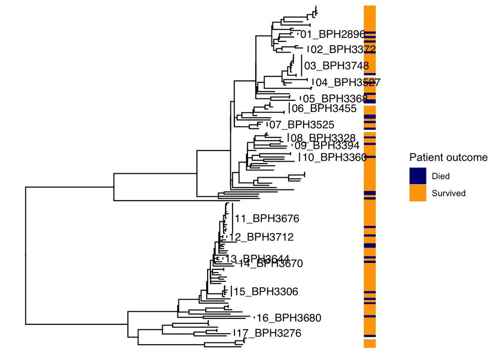

```r
p <- plot_tree_mortality(tree_st239, df_metadata, m_offset = 2e-4)
for (i in unique(df_cluster_monophy %>%  .$cluster_name)){
   node <- get_cluster_mrca(i)
   p <- p +
     geom_cladelabel(node = node, label = i)
 }
p
```

```r
rm(node, i, p)
```

# Add the non CC 239 clusters

What is the dataset of existing clusters?

```r
df_clusters_genetic_dist <- read_csv("Genetic_pairs_analysis_Oct_2020/processed_data/tmp/df_clusters.csv") %>%
  transmute(sample_id = iso, cluster_case_sample_id = str_split_fixed(iso_cluster, "-", 2)[,1], mortality) %>%
  left_join(df_metadata_all %>% select(sample_id, ST)) %>%
  group_by(cluster_case_sample_id) %>%
  filter(!any(ST == "239"))
```

Edit to make like the CC239 clusters df. Note the code to create the cluster id is a very messy attempt to generate a unique id number (starting from 18) based on the order of the clusters on tree.

Note that there are a lot of warnings, probably because fct_relevel is not happy that we use a very long vector from the tree data to relevel a few values in the current dataframe!

```r
df_clusters_genetic_dist <- df_clusters_genetic_dist %>%
  # add cophenetic distance
  left_join(df_dist, by = c("sample_id" = "iso1",
                            "cluster_case_sample_id" = "iso2")) %>%
  # create cluster id
  ungroup() %>%
  # here we reorder the variable cluster case id (defining the lethal strain within the group) based on the order on the tree. We get this order from the y variable in the tree dataframe
  mutate(cluster_case_sample_id = fct_relevel(cluster_case_sample_id, ggtree(tree) %>% .$data %>% arrange(desc(y)) %>% .$label)) %>%
  group_by(cluster_case_sample_id) %>%
  # here we use dplyr::cur_group_id() to generate a unique number id for each group and add it to 17
  mutate(cluster = 17 + cur_group_id()) %>%
  mutate(cluster_name = str_c(formatC(cluster, digits = 1, format = "d", flag = "0"),
                                 "_",
                                 cluster_case_sample_id),
            n_strains = n())
```

Merge in one dataframe

```r
df_cluster_monophy <- df_cluster_monophy %>%
  full_join(df_clusters_genetic_dist)
```

Plot on tree

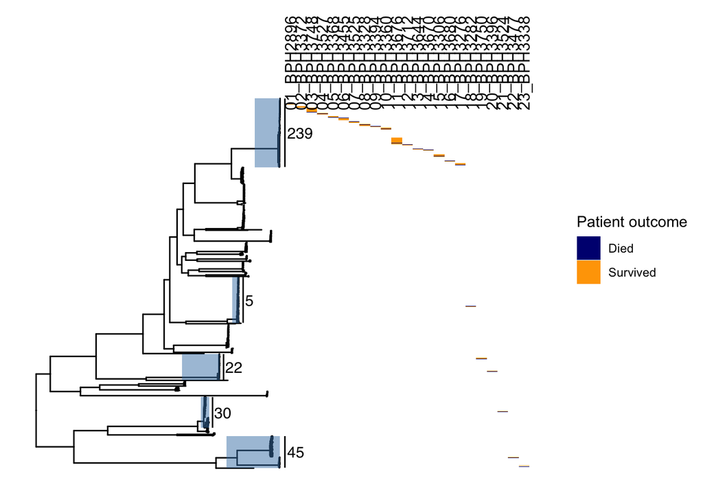

```r
p <- plot_clusters_heatmap(tree, df_cluster_monophy, offset = 80)
st <- unique(df_cluster_monophy$ST) %>% str_subset("-", negate = T)

for (i in st){
  node <- get_st_mrca(i)
  p <- p +
    geom_highlight(node = node) +
    geom_cladelabel(node = node, label = i)
}
p +
  ylim(0, 1000)
```

```r
rm(p, node, i)
```

Explore cophenetic distance again

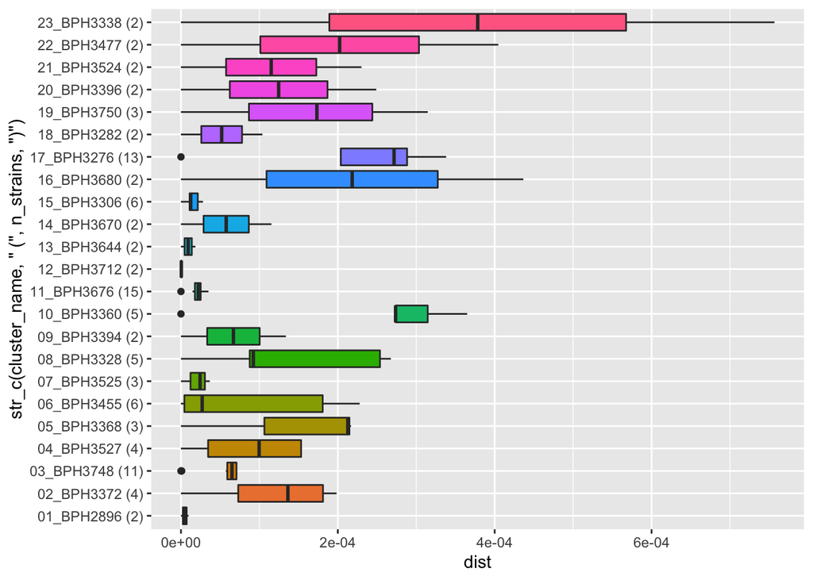

```r
df_cluster_monophy %>%
  ggplot(aes(x = str_c(cluster_name, " (", n_strains, ")"),
             y = dist,
             fill = cluster_name)) +
  geom_boxplot() +
  coord_flip() +
  theme(legend.position = "none")
```

# Export processed data

```r
dir <- "Genetic_pairs_analysis_Oct_2020/processed_data/monophyletic_clusters/"
dir.create(dir)
df_cluster_monophy %>%
  write_csv(str_c(dir, "df_monophyletic_mortality_clusters.csv"))
```